```r
options(OutDec = ".")  # Asegurar punto decimal en este chunk

# Establecer semilla aleatoria para reproducibilidad
set.seed(sample(1:10000, 1))

# Aleatorización del contexto del problema con concordancia de género
contextos_data <- data.frame(
  nombre = c("ciudad", "localidad", "comunidad", "comarca", "provincia", "zona",
             "municipio", "distrito", "territorio", "sector", "barrio", "pueblo"),
  genero = c("f", "f", "f", "f", "f", "f",
             "m", "m", "m", "m", "m", "m"),
  articulo = c("una", "una", "una", "una", "una", "una",
               "un", "un", "un", "un", "un", "un"),
  stringsAsFactors = FALSE
)
contexto_seleccionado <- contextos_data[sample(nrow(contextos_data), 1), ]
contexto <- contexto_seleccionado$nombre
articulo_contexto <- contexto_seleccionado$articulo

# Aleatorización del tipo de competencia con concordancia de género
competencias_data <- data.frame(
  nombre = c("carrera", "competencia atlética", "olimpiada deportiva",
             "justa deportiva", "prueba atlética", "competencia deportiva",
             "maratón", "torneo deportivo", "evento deportivo",
             "campeonato", "concurso deportivo", "certamen deportivo"),
  genero = c("f", "f", "f", "f", "f", "f",
             "m", "m", "m", "m", "m", "m"),
  articulo = c("una", "una", "una", "una", "una", "una",
               "un", "un", "un", "un", "un", "un"),
  stringsAsFactors = FALSE
)
competencia_seleccionada <- competencias_data[sample(nrow(competencias_data), 1), ]
competencia <- competencia_seleccionada$nombre
articulo_competencia <- competencia_seleccionada$articulo

# Aleatorización del grupo de edad
edades <- c(
  "menores de 15 años", "menores de 16 años", "menores de 14 años",
  "niños y niñas de 10 a 15 años", "jóvenes de 12 a 15 años",
  "estudiantes de primaria y secundaria", "categoría infantil",
  "categoría juvenil", "niños y adolescentes", "estudiantes menores de edad"
)
grupo_edad <- sample(edades, 1)

# Aleatorización del premio total (en millones)
# Todos los múltiplos de 2 desde 30 hasta 400 para mayor variabilidad
premios_posibles <- seq(30, 400, by = 2)
premio_total <- sample(premios_posibles, 1)

# Aleatorización de términos para el enunciado
terminos_premiar <- c("premiar", "recompensar", "reconocer", "galardonar", "incentivar")
termino_premiar <- sample(terminos_premiar, 1)

terminos_participantes <- c("participantes", "competidores", "concursantes", "deportistas")
termino_participantes <- sample(terminos_participantes, 1)

terminos_cuenta <- c("cuenta con", "dispone de", "tiene asignados", "ha destinado", "ha reservado")
termino_cuenta <- sample(terminos_cuenta, 1)

terminos_repartiran <- c("repartirán", "distribuirán", "dividirán", "asignarán", "otorgarán")
termino_repartiran <- sample(terminos_repartiran, 1)

terminos_puestos <- c("primeros puestos", "ganadores", "mejores lugares", "primeros lugares")
termino_puestos <- sample(terminos_puestos, 1)

# Aleatorización de términos para dinero con concordancia de género
terminos_dinero_data <- data.frame(
  nombre = c("dinero", "premio", "incentivo", "monto"),
  genero = c("m", "m", "m", "m"),
  articulo_este = c("Este", "Este", "Este", "Este"),
  stringsAsFactors = FALSE
)
termino_dinero_seleccionado <- terminos_dinero_data[sample(nrow(terminos_dinero_data), 1), ]
termino_dinero <- termino_dinero_seleccionado$nombre
articulo_este_dinero <- termino_dinero_seleccionado$articulo_este

# Aleatorización de fracciones para los puestos
# Definimos conjuntos de fracciones más desafiantes que garanticen matemáticamente el orden correcto:
# primer puesto > segundo puesto > tercer puesto
# VERIFICADOS: todos mantienen el orden estricto decreciente pero requieren más cálculo mental
conjuntos_fracciones <- list(
  c("4/7", "2/7"),   # 0.5714 > 0.2857 > 0.1429 ✓ (séptimos)
  c("3/5", "3/14"),  # 0.6000 > 0.2143 > 0.1857 ✓ (catorceavos)
  c("6/11", "3/11"), # 0.5455 > 0.2727 > 0.1818 ✓ (onceavos)
  c("8/17", "5/17"), # 0.4706 > 0.2941 > 0.2353 ✓ (diecisieteavos)
  c("7/16", "5/16"), # 0.4375 > 0.3125 > 0.2500 ✓ (dieciseisavos)
  c("8/15", "4/15"), # 0.5333 > 0.2667 > 0.2000 ✓ (quinceavos)
  c("6/13", "4/13"), # 0.4615 > 0.3077 > 0.2308 ✓ (treceavos)
  c("7/12", "3/12"), # 0.5833 > 0.2500 > 0.1667 ✓ (doceavos)
  c("9/17", "5/17"), # 0.5294 > 0.2941 > 0.1765 ✓ (diecisieteavos)
  c("10/19", "6/19") # 0.5263 > 0.3158 > 0.1579 ✓ (diecinueveavos)
)

# Seleccionar un conjunto aleatorio de fracciones
indice_conjunto <- sample(1:length(conjuntos_fracciones), 1)
fracciones_seleccionadas <- conjuntos_fracciones[[indice_conjunto]]

# Asignar fracciones a los puestos
fraccion_primer_puesto <- fracciones_seleccionadas[1]
fraccion_segundo_puesto <- fracciones_seleccionadas[2]

# Convertir fracciones a valores numéricos para cálculos
convertir_fraccion <- function(fraccion) {
  partes <- strsplit(fraccion, "/")[[1]]
  return(as.numeric(partes[1]) / as.numeric(partes[2]))
}

valor_primer_puesto <- convertir_fraccion(fraccion_primer_puesto)
valor_segundo_puesto <- convertir_fraccion(fraccion_segundo_puesto)

# Calcular la fracción y el valor para el tercer puesto
valor_tercer_puesto <- 1 - (valor_primer_puesto + valor_segundo_puesto)

# Verificar que el valor del tercer puesto sea positivo
test_that("El valor del tercer puesto es positivo", {
  expect_true(valor_tercer_puesto > 0)
})
```

Test passed 🎉

```r
# Calcular los montos exactos en millones para cada puesto
monto_primer_puesto_exacto <- premio_total * valor_primer_puesto
monto_segundo_puesto_exacto <- premio_total * valor_segundo_puesto
monto_tercer_puesto_exacto <- premio_total * valor_tercer_puesto

# Para efectos de presentación, redondear a una decimal si es necesario
monto_primer_puesto <- round(monto_primer_puesto_exacto, 1)
monto_segundo_puesto <- round(monto_segundo_puesto_exacto, 1)
monto_tercer_puesto <- round(monto_tercer_puesto_exacto, 1)

# Ajustar el tercer puesto para asegurar que la suma sea exactamente el premio total
suma_actual <- monto_primer_puesto + monto_segundo_puesto + monto_tercer_puesto
if (abs(suma_actual - premio_total) > 0.1) {
  diferencia <- premio_total - (monto_primer_puesto + monto_segundo_puesto)
  monto_tercer_puesto <- round(diferencia, 1)
}

# Verificar que la suma de los tres montos sea igual al premio total (con tolerancia)
test_that("La suma de los tres montos es igual al premio total", {
  suma_total <- monto_primer_puesto + monto_segundo_puesto + monto_tercer_puesto
  expect_equal(suma_total, premio_total, tolerance = 0.1)
})
```

Test passed 🌈

```r
# Verificar que las fracciones seleccionadas garantizan el orden matemático correcto
# (esto debe ser siempre verdadero con nuestros conjuntos de fracciones corregidos)
test_that("Las fracciones mantienen el orden correcto", {
  expect_true(valor_primer_puesto > valor_segundo_puesto)
  # Usar tolerancia para comparaciones de punto flotante
  expect_true(valor_segundo_puesto >= valor_tercer_puesto - 1e-10)
})
```

Test passed 😀

```r
# Test adicional para verificar que los montos calculados mantienen coherencia
test_that("Los montos calculados son coherentes con las fracciones", {
  # Verificar que los montos exactos corresponden a las fracciones (con tolerancia)
  expect_equal(monto_primer_puesto_exacto, premio_total * valor_primer_puesto, tolerance = 0.01)
  expect_equal(monto_segundo_puesto_exacto, premio_total * valor_segundo_puesto, tolerance = 0.01)
  expect_equal(monto_tercer_puesto_exacto, premio_total * valor_tercer_puesto, tolerance = 0.01)
})
```

Test passed 🌈

```r
# Test para asegurar coherencia: primer puesto > segundo puesto >= tercer puesto
test_that("El primer puesto recibe más que el segundo puesto", {
  expect_true(monto_primer_puesto > monto_segundo_puesto)
})
```

Test passed 🥳

```r
test_that("El segundo puesto recibe al menos tanto como el tercer puesto", {
  # Usar tolerancia para comparaciones de montos redondeados
  expect_true(monto_segundo_puesto >= monto_tercer_puesto - 0.1)
})
```

Test passed 🎉

```r
# Generar opciones de respuesta
# La respuesta correcta es el monto del segundo puesto
respuesta_correcta <- monto_segundo_puesto

# NUEVA ESTRATEGIA: Distractores completamente aleatorios sin patrones predecibles
# para que la respuesta correcta pueda aparecer en cualquier posición

# Generar un pool amplio de distractores candidatos con variación aleatoria
set.seed(NULL)  # Asegurar aleatoriedad real
distractores_candidatos <- c(
  # Variaciones aleatorias MUY amplias para cubrir todo el espectro
  round(respuesta_correcta * runif(4, 0.15, 0.6), 1),                    # 15%-60% del correcto (muy menores)
  round(respuesta_correcta * runif(4, 0.7, 0.95), 1),                    # 70%-95% del correcto (menores)
  round(respuesta_correcta * runif(4, 1.05, 1.8), 1),                    # 105%-180% del correcto (mayores)
  round(respuesta_correcta * runif(4, 2.0, 4.5), 1),                     # 200%-450% del correcto (muy mayores)

  # Errores conceptuales con rangos amplios
  round(premio_total * (valor_primer_puesto * runif(2, 0.2, 1.2)), 1),   # Variación amplia del primer puesto
  round(premio_total * (valor_segundo_puesto * runif(2, 0.3, 1.5)), 1),  # Variación amplia del segundo puesto
  round(premio_total * (valor_tercer_puesto * runif(2, 0.4, 3.0)), 1),   # Variación amplia del tercer puesto

  # Errores de cálculo con rango muy amplio
  round(respuesta_correcta + runif(3, -respuesta_correcta*0.8, respuesta_correcta*2), 1), # Errores proporcionales
  round(respuesta_correcta * runif(3, 0.3, 3.5), 1),                     # Multiplicadores muy amplios

  # Valores completamente aleatorios en rangos pedagógicamente plausibles
  round(runif(3, 5, respuesta_correcta * 0.8), 1),                       # Valores menores aleatorios
  round(runif(3, respuesta_correcta * 1.2, respuesta_correcta * 4), 1)   # Valores mayores aleatorios
)

# Filtrar distractores válidos (diferentes de la respuesta correcta y positivos)
distractores_validos <- distractores_candidatos[distractores_candidatos != respuesta_correcta & distractores_candidatos > 0]

# Asegurar que tenemos suficientes distractores únicos
distractores_validos <- unique(distractores_validos)

# Si no tenemos suficientes, generar algunos adicionales completamente aleatorios
while (length(distractores_validos) < 10) {
  nuevo_distractor <- round(respuesta_correcta * runif(1, 0.2, 3.5), 1)
  if (nuevo_distractor != respuesta_correcta && nuevo_distractor > 0) {
    distractores_validos <- c(distractores_validos, nuevo_distractor)
  }
}

# SELECCIÓN COMPLETAMENTE ALEATORIA - SIN PATRONES FORZADOS
# Simplemente seleccionar 3 distractores al azar del pool disponible
distractores_seleccionados <- sample(distractores_validos, 3)
distractor1 <- distractores_seleccionados[1]
distractor2 <- distractores_seleccionados[2]
distractor3 <- distractores_seleccionados[3]

# Verificación final de unicidad (solo si es necesario)
intentos <- 0
while (length(unique(c(respuesta_correcta, distractor1, distractor2, distractor3))) < 4 && intentos < 3) {
  # Regenerar solo los distractores que causan duplicados
  if (distractor1 == respuesta_correcta || distractor1 == distractor2 || distractor1 == distractor3) {
    distractor1 <- round(respuesta_correcta * runif(1, 0.3, 2.8), 1)
  }
  if (distractor2 == respuesta_correcta || distractor2 == distractor1 || distractor2 == distractor3) {
    distractor2 <- round(respuesta_correcta * runif(1, 0.3, 2.8), 1)
  }
  if (distractor3 == respuesta_correcta || distractor3 == distractor1 || distractor3 == distractor2) {
    distractor3 <- round(respuesta_correcta * runif(1, 0.3, 2.8), 1)
  }
  intentos <- intentos + 1
}

# Crear un vector con todas las opciones y mezclarlas
opciones <- c(respuesta_correcta, distractor1, distractor2, distractor3)
names(opciones) <- c("correcta", "distractor1", "distractor2", "distractor3")
opciones_mezcladas <- sample(opciones)

# Identificar la posición de la respuesta correcta en las opciones mezcladas
indice_correcto <- which(opciones_mezcladas == respuesta_correcta)

# Crear el vector de solución para r-exams
solucion <- rep(0, 4)
solucion[indice_correcto] <- 1

# Aleatorización de colores para la tabla TikZ
paletas_colores <- list(
  c("#4285F4", "#EA4335", "#FBBC05", "#34A853"),  # Google colors
  c("#1F77B4", "#FF7F0E", "#2CA02C", "#D62728"),  # Tableau colors
  c("#003f5c", "#58508d", "#bc5090", "#ff6361"),  # Viridis-like
  c("#0073C2", "#EFC000", "#868686", "#CD534C"),  # IBM colors
  c("#7F3C8D", "#11A579", "#3969AC", "#F2B701")   # Colorbrewer
)
paleta_seleccionada <- sample(paletas_colores, 1)[[1]]
color_encabezado <- paleta_seleccionada[1]
color_primer_puesto <- paleta_seleccionada[2]
color_segundo_puesto <- paleta_seleccionada[3]
color_tercer_puesto <- paleta_seleccionada[4]
```

```r
# Crear código Python para generar la tabla usando matplotlib
codigo_python <- paste0('
import matplotlib
matplotlib.use("Agg")
import matplotlib.pyplot as plt
import matplotlib.patches as patches
from matplotlib.gridspec import GridSpec
import numpy as np

# Configurar colores
color_encabezado = "', color_encabezado, '"
color_primer_puesto = "', color_primer_puesto, '"
color_segundo_puesto = "', color_segundo_puesto, '"
color_tercer_puesto = "', color_tercer_puesto, '"

# Crear figura y configurar grid
fig = plt.figure(figsize=(8, 3.5))
gs = GridSpec(4, 2, height_ratios=[1, 1, 1, 1], width_ratios=[3, 7])

# Encabezado (ocupa todo el ancho)
ax_header = plt.subplot(gs[0, :])
ax_header.set_facecolor(color_encabezado)
ax_header.text(0.5, 0.5, "Distribución del premio de ', premio_total, ' millones de pesos",
              ha="center", va="center", color="white", fontweight="bold", fontsize=11)
ax_header.set_xticks([])
ax_header.set_yticks([])
ax_header.spines["top"].set_visible(True)
ax_header.spines["bottom"].set_visible(True)
ax_header.spines["left"].set_visible(True)
ax_header.spines["right"].set_visible(True)

# Primera fila
ax_p1_label = plt.subplot(gs[1, 0])
ax_p1_label.set_facecolor(color_primer_puesto)
ax_p1_label.text(0.5, 0.5, "Primer puesto", ha="center", va="center", color="white", fontweight="bold", fontsize=10)
ax_p1_label.set_xticks([])
ax_p1_label.set_yticks([])
ax_p1_label.spines["top"].set_visible(True)
ax_p1_label.spines["bottom"].set_visible(True)
ax_p1_label.spines["left"].set_visible(True)
ax_p1_label.spines["right"].set_visible(True)

ax_p1_value = plt.subplot(gs[1, 1])
ax_p1_value.set_facecolor("white")
ax_p1_value.text(0.5, 0.5, "', fraccion_primer_puesto, ' del ', termino_dinero, ' total",
                ha="center", va="center", color="black", fontsize=10)
ax_p1_value.set_xticks([])
ax_p1_value.set_yticks([])
ax_p1_value.spines["top"].set_visible(True)
ax_p1_value.spines["bottom"].set_visible(True)
ax_p1_value.spines["left"].set_visible(True)
ax_p1_value.spines["right"].set_visible(True)

# Segunda fila
ax_p2_label = plt.subplot(gs[2, 0])
ax_p2_label.set_facecolor(color_segundo_puesto)
ax_p2_label.text(0.5, 0.5, "Segundo puesto", ha="center", va="center", color="white", fontweight="bold", fontsize=10)
ax_p2_label.set_xticks([])
ax_p2_label.set_yticks([])
ax_p2_label.spines["top"].set_visible(True)
ax_p2_label.spines["bottom"].set_visible(True)
ax_p2_label.spines["left"].set_visible(True)
ax_p2_label.spines["right"].set_visible(True)

ax_p2_value = plt.subplot(gs[2, 1])
ax_p2_value.set_facecolor("white")
ax_p2_value.text(0.5, 0.5, "', fraccion_segundo_puesto, ' del ', termino_dinero, ' total",
                ha="center", va="center", color="black", fontsize=10)
ax_p2_value.set_xticks([])
ax_p2_value.set_yticks([])
ax_p2_value.spines["top"].set_visible(True)
ax_p2_value.spines["bottom"].set_visible(True)
ax_p2_value.spines["left"].set_visible(True)
ax_p2_value.spines["right"].set_visible(True)

# Tercera fila
ax_p3_label = plt.subplot(gs[3, 0])
ax_p3_label.set_facecolor(color_tercer_puesto)
ax_p3_label.text(0.5, 0.5, "Tercer puesto", ha="center", va="center", color="white", fontweight="bold", fontsize=10)
ax_p3_label.set_xticks([])
ax_p3_label.set_yticks([])
ax_p3_label.spines["top"].set_visible(True)
ax_p3_label.spines["bottom"].set_visible(True)
ax_p3_label.spines["left"].set_visible(True)
ax_p3_label.spines["right"].set_visible(True)

ax_p3_value = plt.subplot(gs[3, 1])
ax_p3_value.set_facecolor("white")
ax_p3_value.text(0.5, 0.5, "el ', termino_dinero, ' restante",
                ha="center", va="center", color="black", fontsize=10)
ax_p3_value.set_xticks([])
ax_p3_value.set_yticks([])
ax_p3_value.spines["top"].set_visible(True)
ax_p3_value.spines["bottom"].set_visible(True)
ax_p3_value.spines["left"].set_visible(True)
ax_p3_value.spines["right"].set_visible(True)

plt.tight_layout(pad=0.5)

# Guardar la figura
plt.savefig("tabla_distribucion.png", dpi=150, bbox_inches="tight")
plt.savefig("tabla_distribucion.pdf", dpi=150, bbox_inches="tight")
plt.close()
')

# Ejecutar código Python para generar la figura
py_run_string(codigo_python)
```

# Question

En una provincia se realizará un concurso deportivo para estudiantes de primaria y secundaria. Para recompensar a los concursantes, la provincia cuenta con 98 millones de pesos, que se asignarán entre los tres primeros lugares, como se indica a continuación:

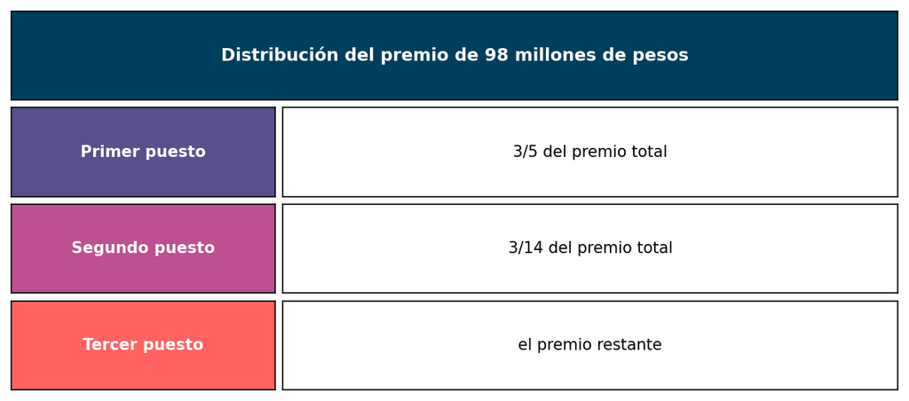

¿Qué cantidad de premio recibirá el segundo puesto?

## Answerlist

- 21 millones.
- 58.6 millones.
- 45.7 millones.
- 17.5 millones.

# Solution

Para resolver este problema, debemos calcular qué cantidad del premio total corresponde al segundo puesto utilizando la fracción indicada en la tabla.

### Paso 1: Identificar los datos del problema

- Premio total: 98 millones de pesos
- Primer puesto: 3/5 del premio total
- Segundo puesto: 3/14 del premio total
- Tercer puesto: el premio restante

### Paso 2: Convertir la fracción del segundo puesto a decimal

- Segundo puesto: 3/14 = 0.2142857

### Paso 3: Calcular el monto en millones de pesos para el segundo puesto

Para calcular el monto que recibirá el segundo puesto, multiplicamos directamente la fracción correspondiente por el premio total:

- Monto del segundo puesto = 3/14 × 98 millones
- Monto del segundo puesto = 0.2142857 × 98 millones
- Monto del segundo puesto = 21 millones
- Redondeando: 21 millones de pesos

**Nota:** Los conjuntos de fracciones utilizados garantizan matemáticamente que el primer puesto siempre reciba más que el segundo, y el segundo más que el tercero, manteniendo la coherencia matemática del problema.

### Verificación

Comprobemos que la suma de los tres montos es igual al premio total:

**Cálculos exactos:**

- Primer puesto: 3/5 × 98 = 58.8 millones
- Segundo puesto: 3/14 × 98 = 21 millones
- Tercer puesto: 0.1857 × 98 = 18.2 millones

**Montos finales (redondeados):**

- Primer puesto: 58.8 millones
- Segundo puesto: 21 millones
- Tercer puesto: 18.2 millones
- **Total: 98 millones**

Como 98 = 98, confirmamos que nuestra respuesta es correcta.

**Por lo tanto, el segundo puesto recibirá 21 millones de pesos.**

## Answerlist

- Verdadero
- Falso
- Falso
- Falso

# Meta-information

exname: fracciones_reparto_premio extype: schoice exsolution: 1000 exshuffle: TRUE exsection: Aritmética|Fracciones|Reparto proporcional